# Intro to Time Series Analysis

Tyrone DeSilva

# Outline

- introducing to time series
- loading the data
- decomposition
  - moving average
  - seasonality
  - residual
- stationarity
  - autocorrelation
  - partial autocorrelation
- differencing
- ARIMA model

Along the way we'll learn about how `pandas` and `statsmodels` are useful tools for handling data.

# Time Series

- Collection of random variables indexed over time(stochastic process)
- Discrete time(fixed interval)
  - E.g. 1/day, 1/month, 1/quarter
- Time domain
- Examples:
  - NYSE
  - Temperature
  - Sound wave

```python
# Load data
import pandas as pd

df = pd.read_csv("data/all_currencies.csv")
df = df.iloc[:, 1:]
df.head()
```

|  | Date | Symbol | Open | High | Low | Close | Volume | Market Cap |
| --- | --- | --- | --- | --- | --- | --- | --- | --- |
| 0 | 2015-11-12 | $$$ | 0.000013 | 0.000017 | 0.000013 | 0.000017 | 142.0 | NaN |
| 1 | 2015-11-13 | $$$ | 0.000017 | 0.000033 | 0.000016 | 0.000024 | 85.0 | NaN |
| 2 | 2015-11-14 | $$$ | 0.000024 | 0.000053 | 0.000023 | 0.000030 | 131.0 | NaN |
| 3 | 2015-11-15 | $$$ | 0.000030 | 0.000063 | 0.000022 | 0.000035 | 132.0 | NaN |
| 4 | 2015-11-16 | $$$ | 0.000035 | 0.000046 | 0.000032 | 0.000036 | 280.0 | NaN |

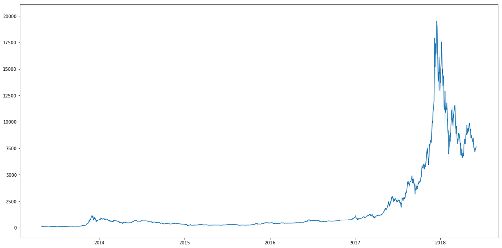

```python
import matplotlib.pyplot as plt
import warnings
warnings.filterwarnings("ignore")

btc_df = df[df["Symbol"] == "BTC"]
btc_df["Date"] = pd.to_datetime(btc_df.loc[:, "Date"])
btc_df = btc_df.set_index("Date")

fig, ax = plt.subplots()

fig.set_size_inches(20, 10)
ax.fill_between(btc_df.index, btc_df.Low, btc_df.High, alpha=0.2)
ax.plot(btc_df.index, btc_df.Close)
```

# Decomposition

- seasonality
- trend
- residual

```python
# Trend Line
from sklearn.linear_model import LinearRegression
import numpy as np

lr = LinearRegression()

x = np.arange(btc_df.shape[0]).reshape(-1, 1)

lr.fit(x, btc_df.Close)
pred = lr.predict(x)
```

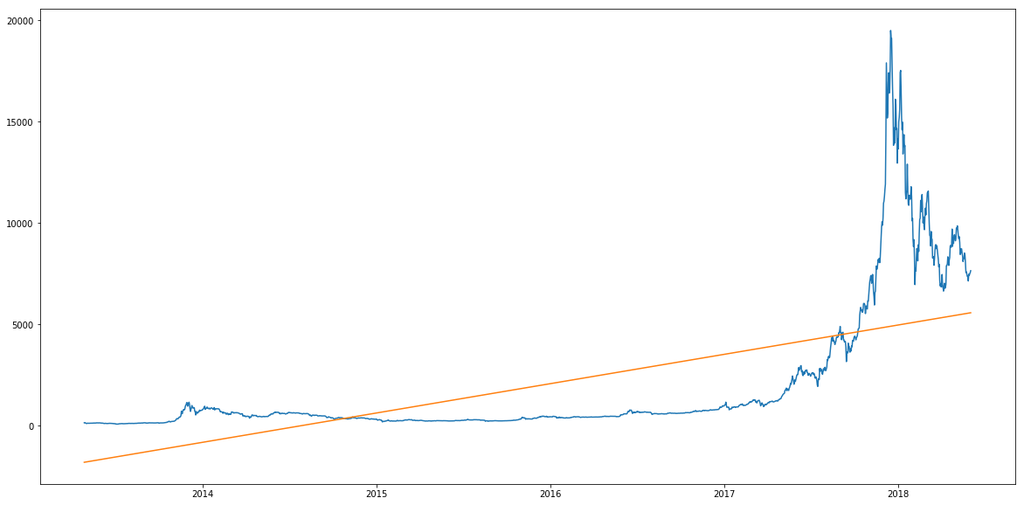

```python
fig, ax = plt.subplots()

fig.set_size_inches(20, 10)
ax.plot(btc_df.index, btc_df.Close)
ax.plot(btc_df.index, pred)
```

#### Moving Average

Moving average involves taking the average of a rolling window of observations. Generally moving average is useful for looking at trend. Looks something like this for odd $w$: $$ \hat{y_i} = \frac{1}{w}\sum_{j=i - \frac{w - 1}{2}}^{i + \frac{w - 1}{2}}{y_j} $$

Enlarging the window smooths out the moving average.

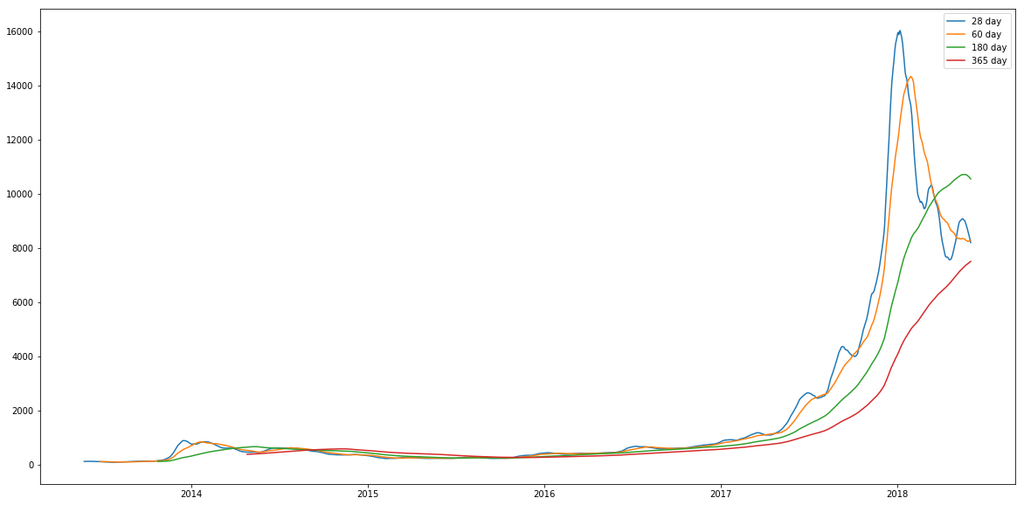

```python
# 28 day moving average window
fig, ax = plt.subplots()

fig.set_size_inches(20, 10)
ax.plot(btc_df.index, btc_df["Close"].rolling(28).mean(), label="28 day")
ax.plot(btc_df.index, btc_df["Close"].rolling(60).mean(), label="60 day")
ax.plot(btc_df.index, btc_df["Close"].rolling(180).mean(), label="180 day")
ax.plot(btc_df.index, btc_df["Close"].rolling(365).mean(), label="365 day")
ax.legend()
```

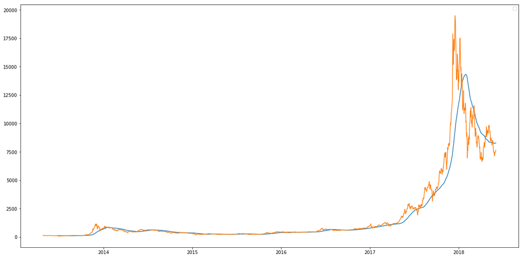

```python
# 60 day moving average window
fig, ax = plt.subplots()

fig.set_size_inches(20, 10)
ax.plot(btc_df.index, btc_df["Close"].rolling(60).mean(), label="60 day MA")
ax.plot(btc_df.Close, label="Actual BTC Close")
ax.legend(())
```

#### Seasonality

- dummy variables for each $i = 1...k$ for period $k$
- e.g. dummy variable for each day of the week when the interval is one week

```python
# de-seasonalize data
# first remove the trend using moving average
moving_average = btc_df.index, btc_df["Close"].rolling(60).mean()
detrended_close = btc_df.Close - moving_average[1]
day_of_week_list = ["monday", "tuesday", "wednesday", "thursday", "friday", "saturday", "sunday"]
days_df = pd.DataFrame({"close": detrended_close,
                        "day": detrended_close.index.map(lambda x: day_of_week_list[x.dayofweek])})
days_df["day"] = days_df["day"].astype("category")
days_df_dummied = pd.get_dummies(days_df)
days_df_dummied.dropna(inplace=True)

x = days_df_dummied.drop(columns="close").values
y = days_df_dummied.close.values

lr = LinearRegression()
lr.fit(x, y)
pred = lr.predict(x)
```

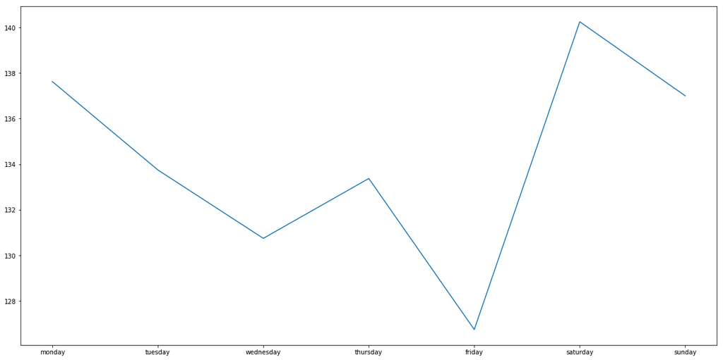

```python
# BTC Price by DoW
fig, ax = plt.subplots()
fig.set_size_inches(20, 10)

ax.plot(days_df_dummied.index[5:12].map(lambda x: day_of_week_list[x.dayofweek]), pred[5:12])
plt.show()
```

#### Residual

Residual is the leftover after seasonality and trend has been removed. Ideally residual should look like gaussian noise.

```python
rolling_average = btc_df["Close"].rolling(60).mean()

days_df = pd.DataFrame({"close": btc_df.Close - rolling_average,
                        "day": btc_df.index.map(lambda x: day_of_week_list[x.dayofweek])})

days_df["day"] = days_df["day"].astype("category")
days_df_dummied = pd.get_dummies(days_df)
days_df_dummied.dropna(inplace=True)

x = days_df_dummied.drop(columns="close").values
y = days_df_dummied.close.values

lr = LinearRegression()
lr.fit(x, y)

pred = lr.predict(x)

residual = btc_df.Close[-pred.shape[0]:] - pred - rolling_average[-pred.shape[0]:]
```

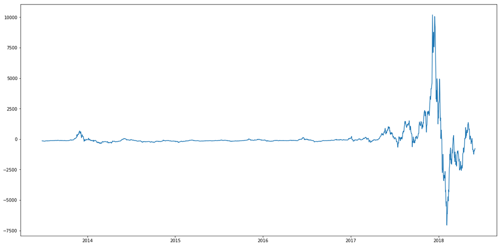

```python
# Residual plot
plt.figure(figsize=(20, 10))
plt.plot(residual)
```

# Stationarity

A time series $\{x_{t_1}, x_{t_2}, ..., x_{t_k}\}$ is said to be stationary if $$ P(x_{t_1} \leq c_1, x_{t_2} \leq c_2, ..., x_{t_k} \leq c_k) = P(x_{t_1 + h} \leq c_1, x_{t_2 + h} \leq c_2, ..., x_{t_k + h} \leq c_k); \forall h \in \mathbb{Z} $$

- no trend, seasonality, periodicity, etc.
- Dickey-Fuller test for stationarity
  - p-value refers to probability of getting data as uncorrelated as the sample given the time series is not stationary

### Quick Intro to Hypothesis Testing

- frequentist statistics
- $H_0$: Data is not stationary
- $H_A$: Data is stationary.
- calculate the probability of getting the data, assuming the null hypothesis
- if $p \lt \alpha$, reject $H_0$

```python
# Dickey-Fuller test for stationarity on BTC data
from statsmodels.tsa.stattools import adfuller

test_fields = ['Test Statistic','p-value','#Lags','Number of Observations Used']

test_results = adfuller(btc_df["Close"])

for field, result in zip(test_fields, test_results[:4]):
    print(f"{field}: {result}")

for key, value in test_results[4].items():
    print(f"Critical value ({key}): {value}")
```

```
Test Statistic: -1.809463376121902
p-value: 0.3757736148339022
#Lags: 22
Number of Observations Used: 1839
Critical value (1%): -3.4339108761687758
Critical value (5%): -2.8631129277746887
Critical value (10%): -2.5676073721917216
```

```python
# Dickey-Fuller test for stationarity on residual
from statsmodels.tsa.stattools import adfuller

test_fields = ['Test Statistic','p-value','#Lags','Number of Observations Used']

test_results = adfuller(residual)

for field, result in zip(test_fields, test_results[:4]):
    print(f"{field}: {result}")

for key, value in test_results[4].items():
    print(f"Critical value ({key}): {value}")
```

```
Test Statistic: -6.949403253722727
p-value: 9.780627188803092e-10
#Lags: 22
Number of Observations Used: 1780
Critical value (1%): -3.434029076071607
Critical value (5%): -2.8631651074657185
Critical value (10%): -2.567635156230274
```

#### Autocorrelation

Autocorrelation looks at the correlation between the values of the exogenous variable at various time lags. The x-axis is the time lag, and the y-axis the correlation for points at that time lag. If we assume our time series is stationary, autocorrelations should only depend on the time lag, i.e. $Cor(x_{t_k}, x_{t_k + h}$ is independent of $t_k$.

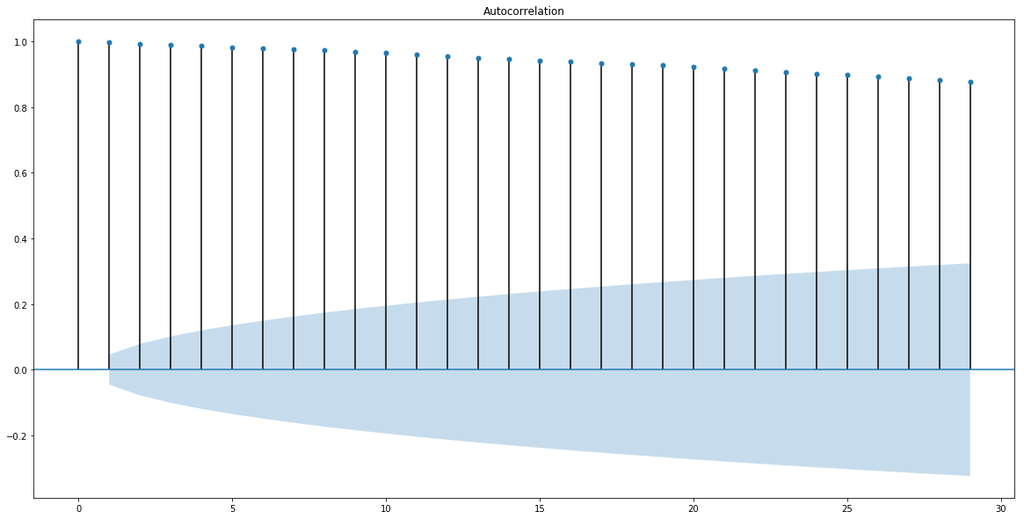

```python
from statsmodels.graphics.tsaplots import plot_acf
import numpy as np

fig, ax = plt.subplots()
fig.set_size_inches((20, 10))

plot_acf(btc_df.Close, lags=np.arange(0, 30), ax=ax)
None
```

#### Partial Autocorrelation

Partial autocorrelation corrects for correlations between smaller time lags when calculating the autocorrelation for a given time lag.

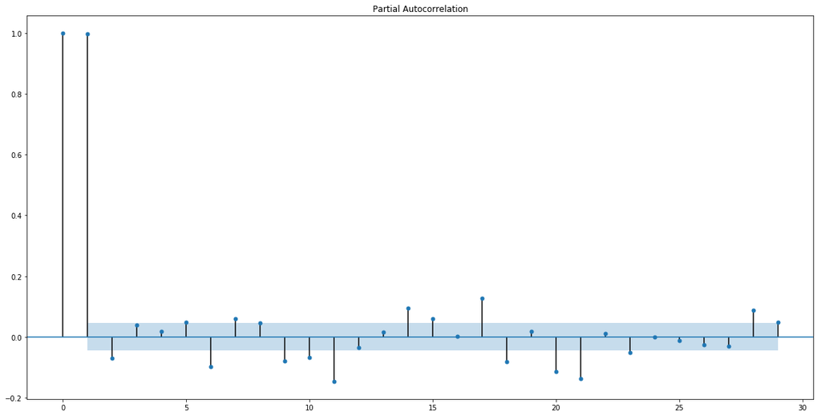

```python
from statsmodels.graphics.tsaplots import plot_pacf


fig, ax = plt.subplots()
fig.set_size_inches((20, 10))
plot_pacf(btc_df.Close, lags=np.arange(0, 30), ax=ax)
None
```

# Differencing

The most simple way of making a time series stationary is differencing. First difference is calculated as: $$ y_2 - y_1, y_3 - y_2, .., y_n - y_{n - 1} $$

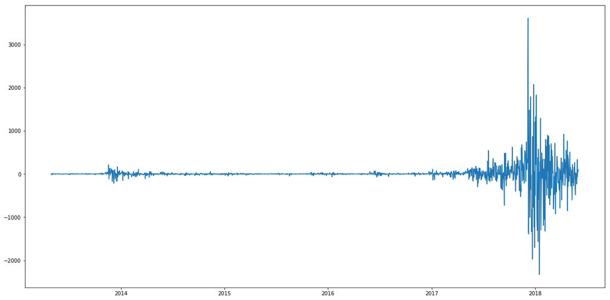

```python
plt.figure(figsize=(20, 10))
plt.plot(btc_df["Close"].diff())
```

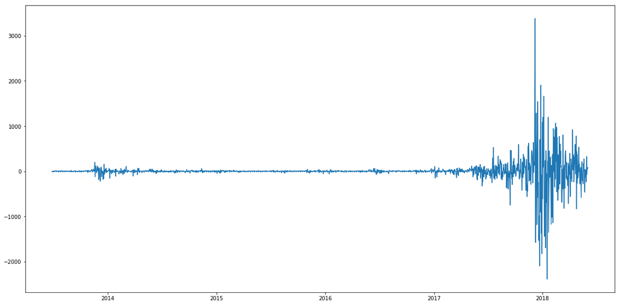

```python
plt.figure(figsize=(20, 10))
plt.plot(residual.diff())
```

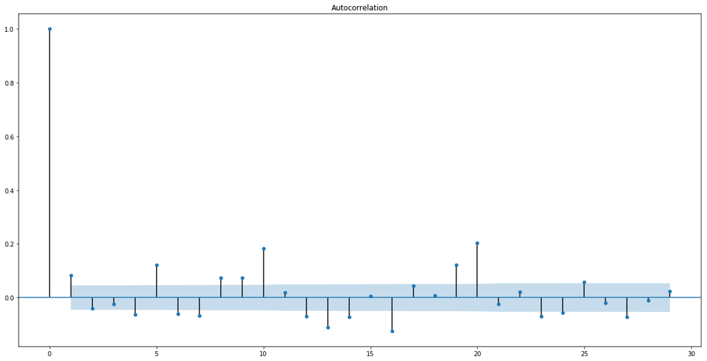

```python
# Autocorrelation of first difference
fig, ax = plt.subplots()
fig.set_size_inches((20, 10))
plot_acf(btc_df.Close.diff().iloc[1:], lags=np.arange(0, 30), ax=ax)
None
```

```python
# Dickey-Fuller test for stationarity
# for residuals
from statsmodels.tsa.stattools import adfuller

test_fields = ['Test Statistic','p-value','#Lags','Number of Observations Used']

test_results = adfuller(btc_df.Close.diff()[1:])

for field, result in zip(test_fields, test_results[:4]):
    print(f"{field}: {result}")

for key, value in test_results[4].items():
    print(f"Critical value ({key}): {value}")
```

```
Test Statistic: -7.325551171898996
p-value: 1.163621091243331e-10
#Lags: 22
Number of Observations Used: 1838
Critical value (1%): -3.4339128162492356
Critical value (5%): -2.863113784245469
Critical value (10%): -2.567607828232656
```

# ARIMA model

- Autoregressive Integrated Moving Average
- makes non-stationary data stationary

#### Autoregression

- infinite impulse response
- if series is stationary, effect of $\epsilon_k$ tends to 0 as $i \rightarrow 0$
- regression on previous values of endogeneous variable $$ X_t = c + \sum_{i=1}^{p}{\varphi_i X_{t - i}} + \epsilon_t $$

#### Moving Average

- finite impulse response
- regression on previous values of the error term $$ X_t = \mu + \epsilon_t + \sum_{i=1}^{q}{\theta_i \epsilon_{t -i}}$$

#### Integrated

- make data stationary via differencing
- fit ARMA model on differences
- integrate differences to get forecasts

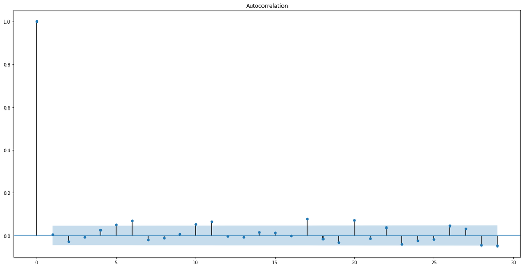

```python
from statsmodels.tsa.arima_model import ARIMA

btc_log = btc_df.Close.map(np.log)

btc_model = ARIMA(btc_log, order=(10, 1, 2)).fit()  # parameters: p, d, q

fig, ax = plt.subplots()
fig.set_size_inches((20, 10))
plot_acf(btc_log.diff().iloc[1:], lags=np.arange(0, 30), ax=ax)
None
```

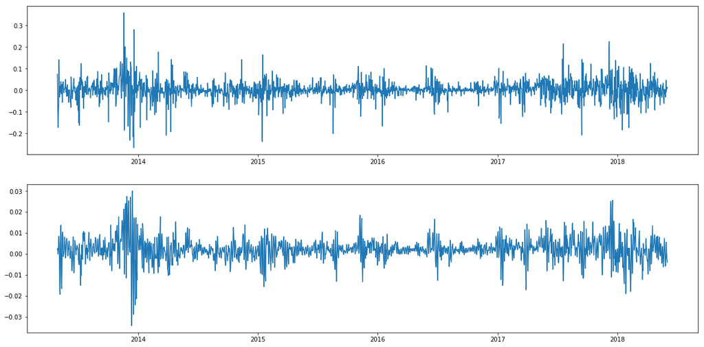

```python
# Plot of actual difference vs predicted difference

fig, ax = plt.subplots(nrows=2)

fig.set_size_inches((20, 10))
ax[0].plot(btc_log.diff())
ax[1].plot(btc_model.predict())
```

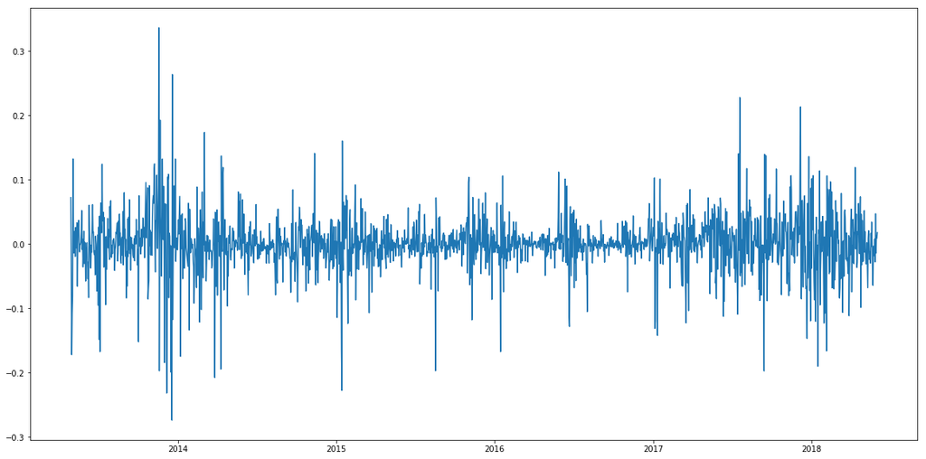

```python
# residual plot
plt.figure(figsize=(20, 10))
plt.plot(btc_model.resid)
```

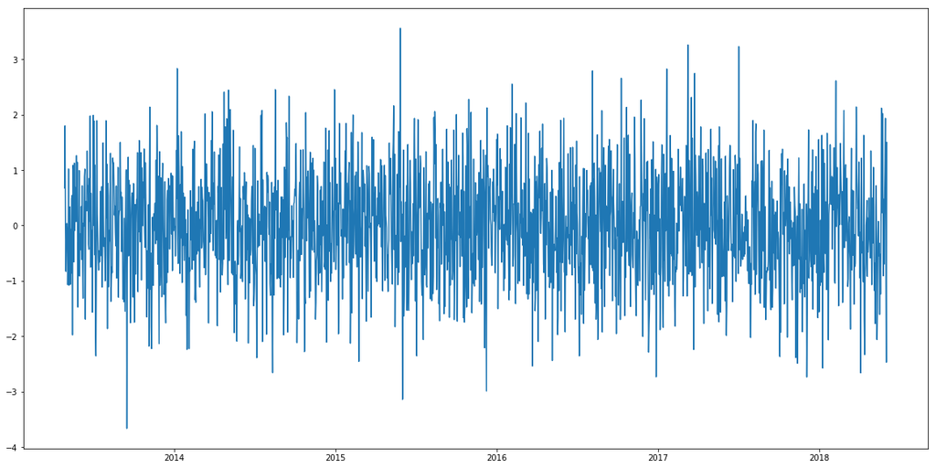

```python
# random noise
from random import gauss

noise = [gauss(0, 1.0) for i in btc_log.index]
white_noise_series = pd.Series(noise, index=btc_log.index)
plt.figure(figsize=(20, 10))
plt.plot(white_noise_series)
```

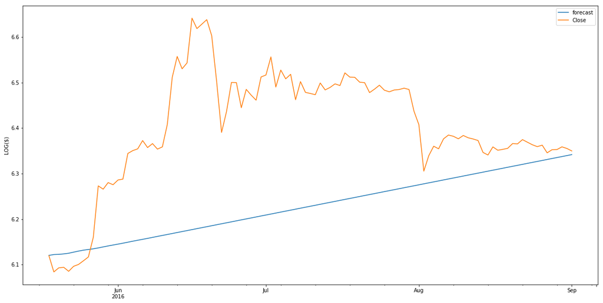

```python
# Prediction for summer 2016, log scale
btc_df.index.freq = "D"
fig, ax = plt.subplots()
fig.set_size_inches((20, 10))
ax.set_ylabel("LOG($)")
btc_model.plot_predict(start="2016-05-18", end="2016-09-01", plot_insample=True, dynamic=True, ax=ax)
None
```

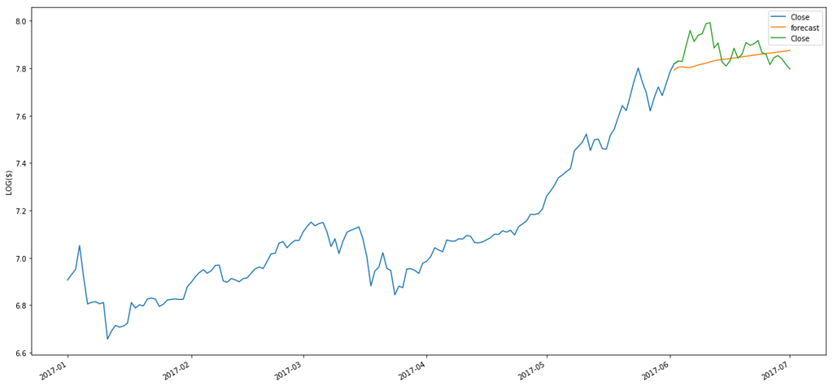

```python
# prediction July through June 2017 with actual
btc_df.index.freq = "D"
fig, ax = plt.subplots()
fig.set_size_inches((20, 10))
ax.plot(pd.DatetimeIndex(start="2017-01-01", end="2017-06-03", freq='D'),
        np.log(btc_df["2017-01-01":"2017-06-03"].Close))
btc_model.plot_predict(start="2017-06-02", end="2017-07-01", plot_insample=True, dynamic=True, ax=ax)
ax.set_ylabel("LOG($)")
None
```

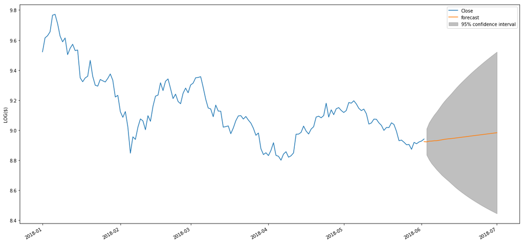

```python
# prediction June to July 2018 with uncertainty
btc_df.index.freq = "D"
fig, ax = plt.subplots()
fig.set_size_inches((20, 10))
ax.plot( pd.DatetimeIndex(start="2018-01-01", end="2018-06-02", freq='D'), np.log(btc_df["2018-01-01":"2018-06-02"].Close))
btc_model.plot_predict(start="2018-06-02", end="2018-07-01", plot_insample=False, dynamic=True, ax=ax)
ax.set_ylabel("LOG($)")
None
```